# Cogalex Results

Simon De Deyne

27 March, 2024

## Bolognesi-2017

The Bolognesi-2017 data consists of 185 distinct English cue words and 1207 unique responses. The responses are semantic features consisting primarily of single-word responses. In contrast to the other datasets, many of the cue words are abstract.

## Vivas-2022 Features

The Vivas-2022 consists of 400 distinct English cue words and 1199 unique responses. The responses were carefully preprocessed resulting in a highly consistent set of semantic features.

## Vivas-2022 Associations

The Vivas-2022 feature data were recoded by extracting a single keyword from every multiword response. The obtained responses are in this way similar to assocation data in that they censor additional cues about the underlying semantic relation. The datast consists of 400 distinct English cue words and 964 unique responses.

## Chen-2024

The Chen-2024 data consist of 505 distinct English cue words and 1350 unique responses. Unlike the other datasets, annotations for two coders A and B are available. Unless stated otherwise, the presented results are those based on coder A.

## Liu-2022

The Liu-2022 data consist of 340 distinct English cue words and 414 unique responses.

# Type-based balanced accuracy scores

## Macro results

Macro-level results cover the top-level distinctions in the ontology. These are shared among all datasets and include Taxonomic relations, Concept properties, Situation properties, and Introspective properties.

| dataset | accuracy | NIR | p | Kappa | precision | recall | F1 |
| --- | --- | --- | --- | --- | --- | --- | --- |
| Bolognesi-2017 | 0.717 | 0.388 | 0 | 0.609 | 0.765 | 0.717 | 0.730 |
| Vivas 2022 Features | 0.846 | 0.438 | 0 | 0.768 | 0.867 | 0.846 | 0.851 |
| Vivas 2022 Asso | 0.846 | 0.401 | 0 | 0.769 | 0.852 | 0.846 | 0.847 |
| Chen-2024A | 0.763 | 0.419 | 0 | 0.653 | 0.769 | 0.763 | 0.764 |
| Chen-2024B | 0.713 | 0.419 | 0 | 0.584 | 0.738 | 0.713 | 0.716 |
| Chen-2024AB | 0.880 | 0.357 | 0 | 0.825 | 0.888 | 0.880 | 0.879 |
| Liu 2022 | 0.718 | 0.420 | 0 | 0.562 | 0.758 | 0.718 | 0.727 |

## Micro results

| dataset | accuracy | NIR | p | Kappa | precision | recall | F1 |
| --- | --- | --- | --- | --- | --- | --- | --- |
| Bolognesi-2017 | 0.542 | 0.116 | 0 | 0.510 | 0.647 | 0.542 | 0.564 |
| Vivas 2022 Features | 0.614 | 0.207 | 0 | 0.584 | 0.720 | 0.614 | 0.618 |
| Vivas 2022 Asso | 0.599 | 0.129 | 0 | 0.571 | 0.623 | 0.599 | 0.577 |
| Chen-2024A | 0.523 | 0.194 | 0 | 0.487 | 0.615 | 0.523 | 0.536 |
| Chen-2024B | 0.492 | 0.194 | 0 | 0.454 | 0.607 | 0.492 | 0.499 |
| Chen-2024AB | 0.808 | 0.127 | 0 | 0.794 | 0.822 | 0.808 | 0.809 |
| Liu 2022 | 0.464 | 0.282 | 0 | 0.399 | 0.535 | 0.464 | 0.471 |

# Token-based balanced accuracy scores

## Macro results

| dataset | accuracy | NIR | p | Kappa | precision | recall | F1 |
| --- | --- | --- | --- | --- | --- | --- | --- |
| Bolognesi-2017 | 0.733 | 0.389 | 0 | 0.630 | 0.778 | 0.733 | 0.746 |
| Vivas 2022 Features | 0.865 | 0.414 | 0 | 0.797 | 0.882 | 0.865 | 0.869 |
| Vivas 2022 Asso | 0.860 | 0.409 | 0 | 0.791 | 0.865 | 0.860 | 0.861 |
| Chen-2024A | 0.780 | 0.422 | 0 | 0.676 | 0.787 | 0.780 | 0.781 |
| Chen-2024B | 0.730 | 0.422 | 0 | 0.606 | 0.755 | 0.730 | 0.732 |
| Chen-2024AB | 0.884 | 0.344 | 0 | 0.830 | 0.893 | 0.884 | 0.884 |
| Liu 2022 | 0.723 | 0.407 | 0 | 0.574 | 0.762 | 0.723 | 0.729 |

## Micro results

| dataset | accuracy | NIR | p | Kappa | precision | recall | F1 |
| --- | --- | --- | --- | --- | --- | --- | --- |
| Bolognesi-2017 | 0.566 | 0.126 | 0 | 0.535 | 0.664 | 0.566 | 0.586 |
| Vivas 2022 Features | 0.622 | 0.225 | 0 | 0.591 | 0.726 | 0.622 | 0.623 |
| Vivas 2022 Asso | 0.594 | 0.138 | 0 | 0.565 | 0.606 | 0.594 | 0.565 |
| Chen-2024A | 0.540 | 0.194 | 0 | 0.502 | 0.624 | 0.540 | 0.549 |
| Chen-2024B | 0.507 | 0.194 | 0 | 0.468 | 0.614 | 0.507 | 0.509 |
| Chen-2024AB | 0.816 | 0.139 | 0 | 0.801 | 0.830 | 0.816 | 0.817 |
| Liu 2022 | 0.489 | 0.272 | 0 | 0.425 | 0.544 | 0.489 | 0.491 |

# Confusion matrices

All confusion matrices are based on token-based results.

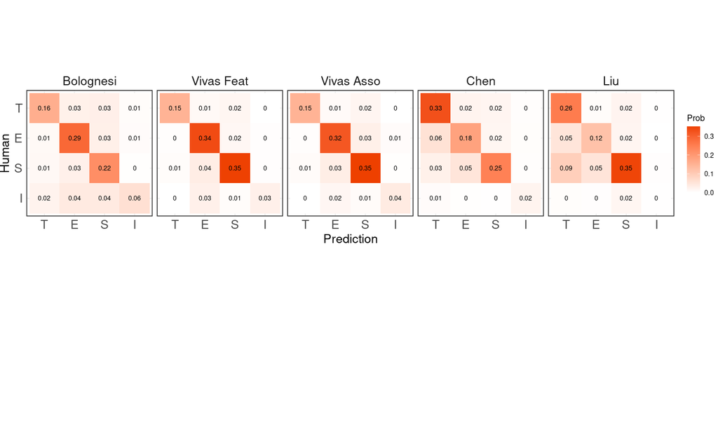

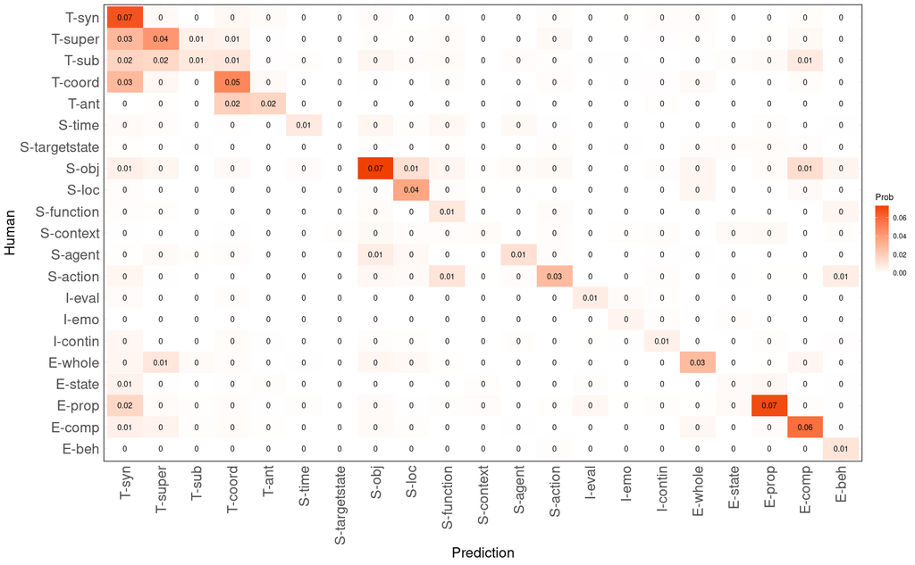

### Micro-level Confusion Matrix Liu-2022

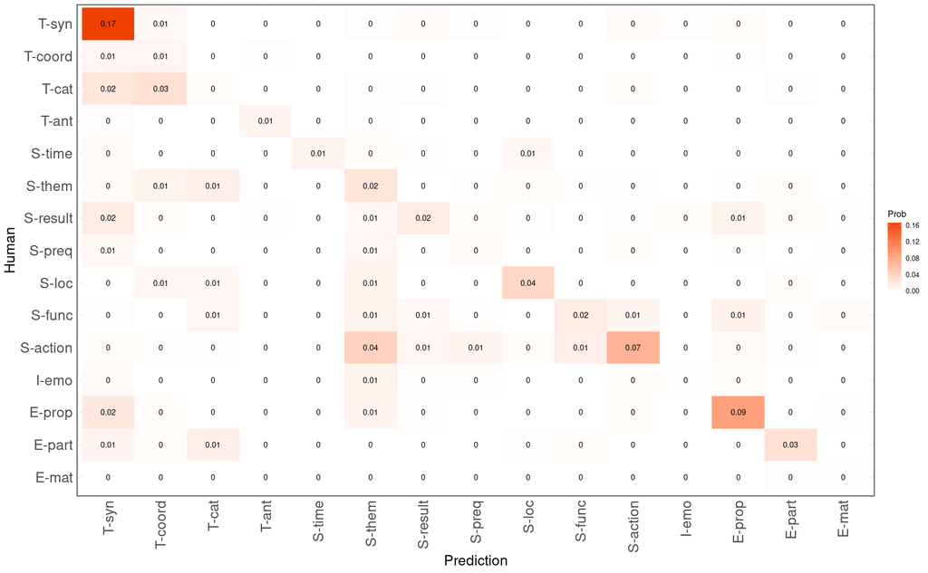

### Human vs LLM F-scores

The following plot shows the F-scores for the weighted micro-level results. The dot-size indicates the prevalence of a specific relation type. The vertical position of the dots indicate relative higher agreement between a model and annotator A (left panel) or B (right panel) compared to human annotator agreement (x-axis or horizontal position).

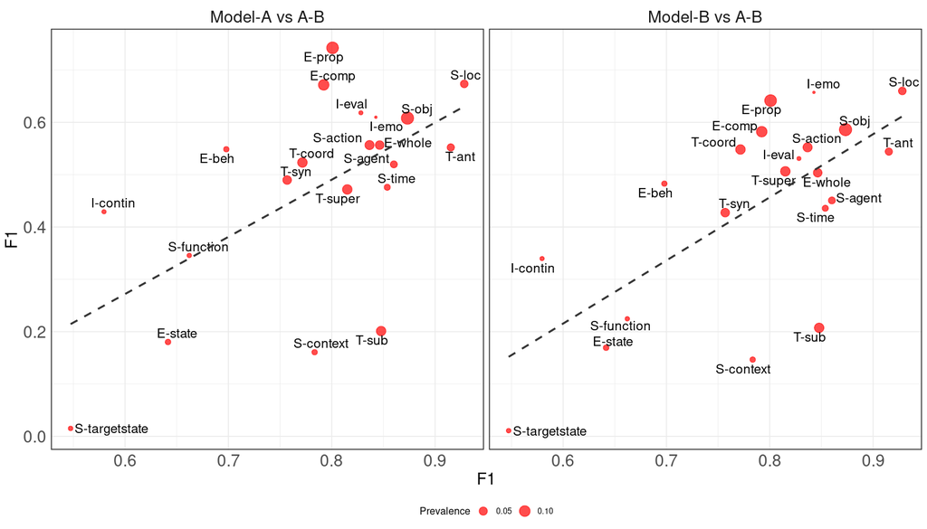